# Expressing Uncertainty

Claire Dudley

3/8/2022

This mini tutorial is focused on expressing variability, which is important to do when presenting data visually. It is important to showcase variability and not just means, as some graphs do, like bar plots. For this tutorial, I will be using the mlb dataset representing mlb players’ salary statistics. I will be just using the variables Team and Salary.

```r
library(tidyverse)
library(here)
mlb_df <- read_csv(here("data/mlb2016.csv"))
```

```r
mlb_df$Salary = substring(mlb_df$Salary, 2)
mlb_df$Salary <- as.numeric(gsub(",","", mlb_df$Salary))
mlb_df$Team <- fct_reorder(mlb_df$Team, -mlb_df$Salary, mean)
```

```
## No summary function supplied, defaulting to `mean_se()`
```

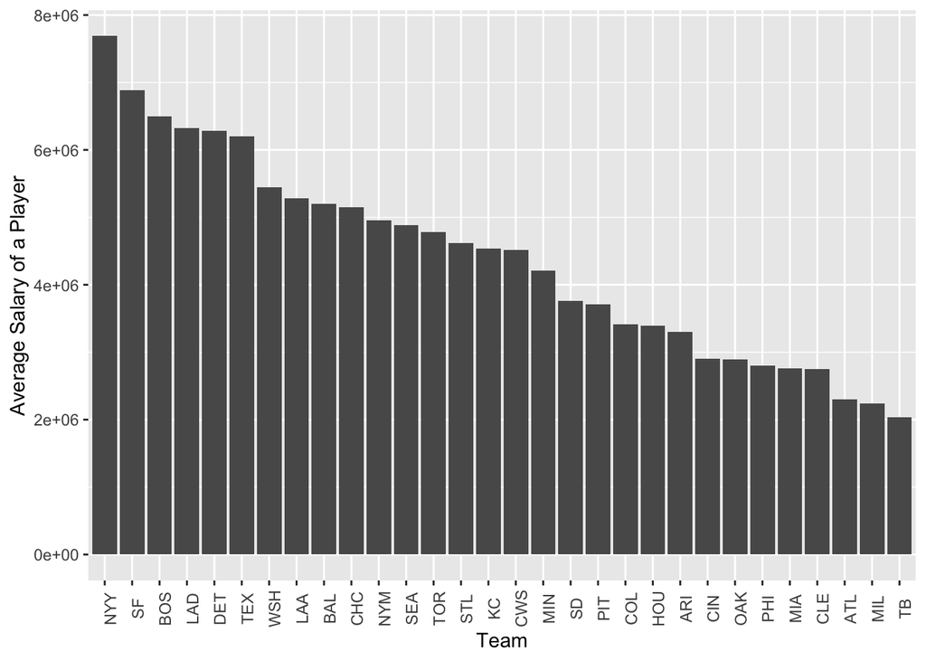

```r
ggplot(data = mlb_df, aes(x = Team, y = Salary)) +
  geom_bar(stat = "summary") +
  labs(x = "Team", y = "Average Salary of a Player") +
  theme(axis.text.x = element_text(angle = 90))
```

```r
mlb_df2 <-
  mlb_df %>%
  group_by(Team) %>%
summarise(meansal = mean(Salary),
            sdsal = sd(Salary),
            nsal = n()) %>%
  mutate(l_se = meansal - sdsal / sqrt(nsal),
         u_se = meansal + sdsal / sqrt(nsal))
```

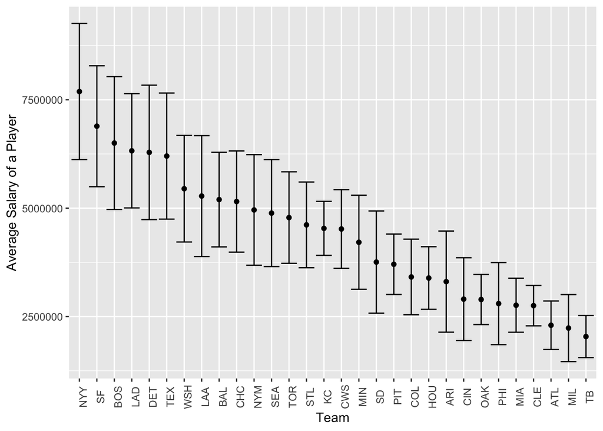

```r
ggplot(data = mlb_df2, aes(x = Team,
                              y = meansal)) +
  geom_point() +
  geom_errorbar(aes(ymin = l_se, ymax = u_se)) +
  labs(x = "Team",
       y = "Average Salary of a Player") +
  theme(axis.text.x = element_text(angle = 90))
```

We can also use boxplots to even better show variability:

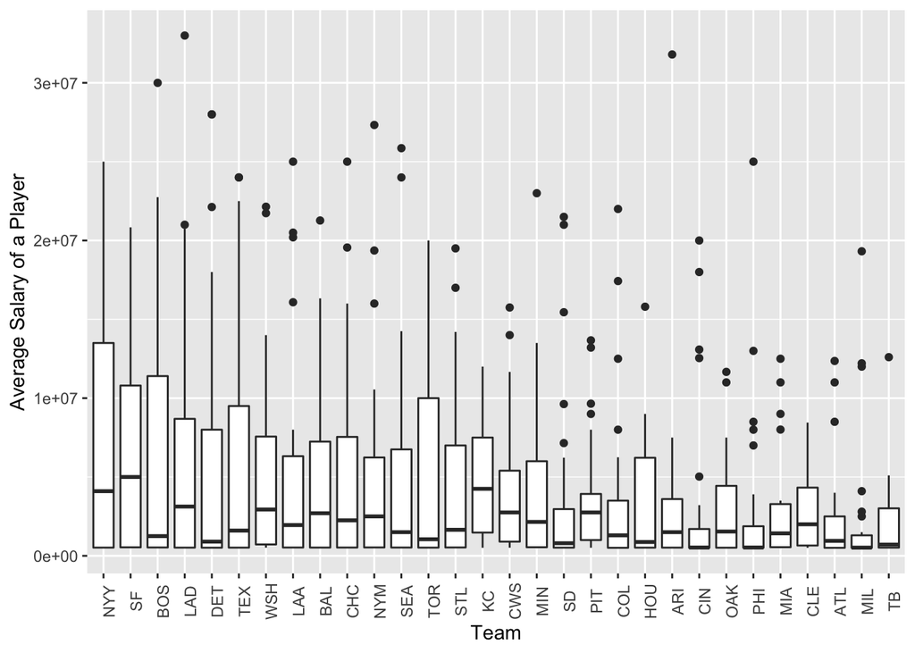

```r
ggplot(data = mlb_df, aes(x = Team, y = Salary)) +
  geom_boxplot()  +
   labs(x = "Team",
       y = "Average Salary of a Player") +
  theme(axis.text.x = element_text(angle = 90))
```

After looking at the first two graphs, we may assume that the New York Yankees pay all of their players a lot more than Tampa Bay, but looking at the third graph, clearly the elite players on the highest paid teams are pulling up their average quite a bit.